# Part I - (Dataset Exploration: Loan Data from Prosper)

## Introduction

This data set contains 113,937 loans with 81 variables on each loan, including loan amount, borrower rate (or interest rate), current loan status, borrower income, and many others.

### Definition of Variables

- **ListingKey** : Unique key for each listing, same value as the 'key' used in the listing object in the API.
- **ListingNumber** : The number that uniquely identifies the listing to the public as displayed on the website.
- **ListingCreationDate** : The date the listing was created.
- **CreditGrade** : The Credit rating that was assigned at the time the listing went live. Applicable for listings pre-2009 period and will only be populated for those listings.
- **Term** : The length of the loan expressed in months.
- **LoanStatus** : The current status of the loan: Cancelled, Chargedoff, Completed, Current, Defaulted, FinalPaymentInProgress, PastDue. The PastDue status will be accompanied by a delinquency bucket.
- **ClosedDate** : Closed date is applicable for Cancelled, Completed, Chargedoff and Defaulted loan statuses.
- **BorrowerAPR** : The Borrower's Annual Percentage Rate (APR) for the loan.
- **BorrowerRate** : The Borrower's interest rate for this loan.
- **LenderYield** : The Lender yield on the loan. Lender yield is equal to the interest rate on the loan less the servicing fee.
- **EstimatedEffectiveYield** : Effective yield is equal to the borrower interest rate (i) minus the servicing fee rate, (ii) minus estimated uncollected interest on charge-offs, (iii) plus estimated collected late fees. Applicable for loans originated after July 2009.
- **EstimatedLoss** : Estimated loss is the estimated principal loss on charge-offs. Applicable for loans originated after July 2009.
- **EstimatedReturn** : The estimated return assigned to the listing at the time it was created. Estimated return is the difference between the Estimated Effective Yield and the Estimated Loss Rate. Applicable for loans originated after July 2009.
- **ProsperRating (numeric)** : The Prosper Rating assigned at the time the listing was created: 0 - N/A, 1 - HR, 2 - E, 3 - D, 4 - C, 5 - B, 6 - A, 7 - AA. Applicable for loans originated after July 2009.
- **ProsperRating (Alpha)** : The Prosper Rating assigned at the time the listing was created between AA - HR. Applicable for loans originated after July 2009.
- **ProsperScore** : A custom risk score built using historical Prosper data. The score ranges from 1-10, with 10 being the best, or lowest risk score. Applicable for loans originated after July 2009.
- **ListingCategory** : The category of the listing that the borrower selected when posting their listing: 0 - Not Available, 1 - Debt Consolidation, 2 - Home Improvement, 3 - Business, 4 - Personal Loan, 5 - Student Use, 6 - Auto, 7- Other, 8 - Baby&Adoption, 9 - Boat, 10 - Cosmetic Procedure, 11 - Engagement Ring, 12 - Green Loans, 13 - Household Expenses, 14 - Large Purchases, 15 - Medical/Dental, 16 - Motorcycle, 17 - RV, 18 - Taxes, 19 - Vacation, 20 - Wedding Loans
- **BorrowerState** : The two letter abbreviation of the state of the address of the borrower at the time the Listing was created.
- **Occupation** : The Occupation selected by the Borrower at the time they created the listing.
- **EmploymentStatus** : The employment status of the borrower at the time they posted the listing.
- **EmploymentStatusDuration** : The length in months of the employment status at the time the listing was created.
- **IsBorrowerHomeowner** : A Borrower will be classified as a homowner if they have a mortgage on their credit profile or provide documentation confirming they are a homeowner.
- **CurrentlyInGroup** : Specifies whether or not the Borrower was in a group at the time the listing was created.
- **GroupKey** : The Key of the group in which the Borrower is a member of. Value will be null if the borrower does not have a group affiliation.
- **DateCreditPulled** : The date the credit profile was pulled.
- **CreditScoreRangeLower** : The lower value representing the range of the borrower's credit score as provided by a consumer credit rating agency.
- **CreditScoreRangeUpper** : The upper value representing the range of the borrower's credit score as provided by a consumer credit rating agency.
- **FirstRecordedCreditLine** : The date the first credit line was opened.
- **CurrentCreditLines** : Number of current credit lines at the time the credit profile was pulled.
- **OpenCreditLines** : Number of open credit lines at the time the credit profile was pulled.
- **TotalCreditLinespast7years** : Number of credit lines in the past seven years at the time the credit profile was pulled.
- **OpenRevolvingAccounts** : Number of open revolving accounts at the time the credit profile was pulled.
- **OpenRevolvingMonthlyPayment** : Monthly payment on revolving accounts at the time the credit profile was pulled.
- **InquiriesLast6Months** : Number of inquiries in the past six months at the time the credit profile was pulled.
- **TotalInquiries** : Total number of inquiries at the time the credit profile was pulled.
- **CurrentDelinquencies** : Number of accounts delinquent at the time the credit profile was pulled.
- **AmountDelinquent** : Dollars delinquent at the time the credit profile was pulled.
- **DelinquenciesLast7Years** : Number of delinquencies in the past 7 years at the time the credit profile was pulled.
- **PublicRecordsLast10Years** : Number of public records in the past 10 years at the time the credit profile was pulled.
- **PublicRecordsLast12Months** : Number of public records in the past 12 months at the time the credit profile was pulled.
- **RevolvingCreditBalance** : Dollars of revolving credit at the time the credit profile was pulled.
- **BankcardUtilization** : The percentage of available revolving credit that is utilized at the time the credit profile was pulled.
- **AvailableBankcardCredit** : The total available credit via bank card at the time the credit profile was pulled.
- **TotalTrades** : Number of trade lines ever opened at the time the credit profile was pulled.
- **TradesNeverDelinquent** : Number of trades that have never been delinquent at the time the credit profile was pulled.
- **TradesOpenedLast6Months** : Number of trades opened in the last 6 months at the time the credit profile was pulled.
- **DebtToIncomeRatio** : The debt to income ratio of the borrower at the time the credit profile was pulled. This value is Null if the debt to income ratio is not available. This value is capped at 10.01 (any debt to income ratio larger than 1000% will be returned as 1001%).
- **IncomeRange** : The income range of the borrower at the time the listing was created.
- **IncomeVerifiable** : The borrower indicated they have the required documentation to support their income.
- **StatedMonthlyIncome** : The monthly income the borrower stated at the time the listing was created.
- **LoanKey : Unique key for each loan. This is the same key that is used in the API.
- **TotalProsperLoans** : Number of Prosper loans the borrower at the time they created this listing. This value will be null if the borrower had no prior loans.
- **TotalProsperPaymentsBilled** : Number of on time payments the borrower made on Prosper loans at the time they created this listing. This value will be null if the borrower had no prior loans.
- **OnTimeProsperPayments** : Number of on time payments the borrower had made on Prosper loans at the time they created this listing. This value will be null if the borrower has no prior loans.
- **ProsperPaymentsLessThanOneMonthLate** : Number of payments the borrower made on Prosper loans that were less than one month late at the time they created this listing. This value will be null if the borrower had no prior loans.
- **ProsperPaymentsOneMonthPlusLate** : Number of payments the borrower made on Prosper loans that were greater than one month late at the time they created this listing. This value will be null if the borrower had no prior loans.
- **ProsperPrincipalBorrowed** : Total principal borrowed on Prosper loans at the time the listing was created. This value will be null if the borrower had no prior loans.
- **ProsperPrincipalOutstanding** : Principal outstanding on Prosper loans at the time the listing was created. This value will be null if the borrower had no prior loans.
- **ScorexChangeAtTimeOfListing** : Borrower's credit score change at the time the credit profile was pulled. This will be the change relative to the borrower's last Prosper loan. This value will be null if the borrower had no prior loans.
- **LoanCurrentDaysDelinquent** : The number of days delinquent.
- **LoanFirstDefaultedCycleNumber** : The cycle the loan was charged off. If the loan has not charged off the value will be null.
- **LoanMonthsSinceOrigination** : Number of months since the loan originated.
- **LoanNumber** : Unique numeric value associated with the loan.
- **LoanOriginalAmount** : The origination amount of the loan.
- **LoanOriginationDate** : The date the loan was originated.
- **LoanOriginationQuarter** : The quarter in which the loan was originated.
- **MemberKey** : The unique key that is associated with the borrower. This is the same identifier that is used in the API member object.
- **MonthlyLoanPayment** : The scheduled monthly loan payment.
- **LP_CustomerPayments** : Pre charge-off cumulative gross payments made by the borrower on the loan. If the loan has charged off, this value will exclude any recoveries.
- **LP_CustomerPrincipalPayments** : Pre charge-off cumulative principal payments made by the borrower on the loan. If the loan has charged off, this value will exclude any recoveries.
- **LP_InterestandFees** : Pre charge-off cumulative interest and fees paid by the borrower. If the loan has charged off, this value will exclude any recoveries.
- **LP_ServiceFees** : Cumulative service fees paid by the investors who have invested in the loan.
- **LP_CollectionFees** : Cumulative collection fees paid by the investors who have invested in the loan.
- **LP_GrossPrincipalLoss** : The gross charged off amount of the loan.
- **LP_NetPrincipalLoss** : The principal that remains uncollected after any recoveries.
- **LP_NonPrincipalRecoverypayments** : The interest and fee component of any recovery payments. The current payment policy applies payments in the following order: Fees, interest, principal.
- **PercentFunded** : Percent the listing was funded.
- **Recommendations** : Number of recommendations the borrower had at the time the listing was created.
- **InvestmentFromFriendsCount** : Number of friends that made an investment in the loan.
- **InvestmentFromFriendsAmount** : Dollar amount of investments that were made by friends.
- **Investors** : The number of investors that funded the loan.

## Preliminary Wrangling

```python
# import all packages and set plots to be embedded inline
import numpy as np
import pandas as pd
import matplotlib.pyplot as plt
import seaborn as sb
import warnings

from pandas.api.types import CategoricalDtype

warnings.filterwarnings('ignore')
%matplotlib inline
```

> Load in your dataset and describe its properties through the questions below. Try and motivate your exploration goals through this section.

```python
#Load the dataset
loan = pd.read_csv('prosperLoanData.csv')
```

```python
#overview of sample rows
loan.head(5)
```

|  | ListingKey | ListingNumber | ListingCreationDate | CreditGrade | Term | LoanStatus | ClosedDate | BorrowerAPR | BorrowerRate | LenderYield | ... | LP_ServiceFees | LP_CollectionFees | LP_GrossPrincipalLoss | LP_NetPrincipalLoss | LP_NonPrincipalRecoverypayments | PercentFunded | Recommendations | InvestmentFromFriendsCount | InvestmentFromFriendsAmount | Investors |
| --- | --- | --- | --- | --- | --- | --- | --- | --- | --- | --- | --- | --- | --- | --- | --- | --- | --- | --- | --- | --- | --- |
| 0 | 1021339766868145413AB3B | 193129 | 2007-08-26 19:09:29.263000000 | C | 36 | Completed | 2009-08-14 00:00:00 | 0.16516 | 0.1580 | 0.1380 | ... | -133.18 | 0.0 | 0.0 | 0.0 | 0.0 | 1.0 | 0 | 0 | 0.0 | 258 |
| 1 | 10273602499503308B223C1 | 1209647 | 2014-02-27 08:28:07.900000000 | NaN | 36 | Current | NaN | 0.12016 | 0.0920 | 0.0820 | ... | 0.00 | 0.0 | 0.0 | 0.0 | 0.0 | 1.0 | 0 | 0 | 0.0 | 1 |
| 2 | 0EE9337825851032864889A | 81716 | 2007-01-05 15:00:47.090000000 | HR | 36 | Completed | 2009-12-17 00:00:00 | 0.28269 | 0.2750 | 0.2400 | ... | -24.20 | 0.0 | 0.0 | 0.0 | 0.0 | 1.0 | 0 | 0 | 0.0 | 41 |
| 3 | 0EF5356002482715299901A | 658116 | 2012-10-22 11:02:35.010000000 | NaN | 36 | Current | NaN | 0.12528 | 0.0974 | 0.0874 | ... | -108.01 | 0.0 | 0.0 | 0.0 | 0.0 | 1.0 | 0 | 0 | 0.0 | 158 |
| 4 | 0F023589499656230C5E3E2 | 909464 | 2013-09-14 18:38:39.097000000 | NaN | 36 | Current | NaN | 0.24614 | 0.2085 | 0.1985 | ... | -60.27 | 0.0 | 0.0 | 0.0 | 0.0 | 1.0 | 0 | 0 | 0.0 | 20 |

5 rows × 81 columns

```python
#Structure of the data in terms of Rows and columns
loan.shape
```

```
(113937, 81)
```

```python
#Checking on dataset structure, data types and missing values.

loan.info()
```

```
<class 'pandas.core.frame.DataFrame'>
RangeIndex: 113937 entries, 0 to 113936
Data columns (total 81 columns):
 #   Column                               Non-Null Count   Dtype
---  ------                               --------------   -----
 0   ListingKey                           113937 non-null  object
 1   ListingNumber                        113937 non-null  int64
 2   ListingCreationDate                  113937 non-null  object
 3   CreditGrade                          28953 non-null   object
 4   Term                                 113937 non-null  int64
 5   LoanStatus                           113937 non-null  object
 6   ClosedDate                           55089 non-null   object
 7   BorrowerAPR                          113912 non-null  float64
 8   BorrowerRate                         113937 non-null  float64
 9   LenderYield                          113937 non-null  float64
```

[output cut: 73 more lines]

#### Variables of Interest from the dataset (with index id)

- 2 ListingCreationDate
- 4 Term
- 5 LoanStatus
- 7 BorrowerAPR
- 8 BorrowerRate
- 9 LenderYield
- 16 ListingCategory (numeric)
- 19 EmploymentStatus
- 20 EmploymentStatusDuration
- 21 IsBorrowerHomeowner
- 47 IncomeRange
- 48 IncomeVerifiable
- 49 StatedMonthlyIncome
- 63 LoanOriginalAmount
- 64 LoanOriginationDate
- 65 LoanOriginationQuarter
- 67 MonthlyLoanPayment

  > Create a new dataset from this variables

```python
#Create new dataset to visualize with variables of interest from the dataset (Atleast 15 Variables)

df = loan.iloc[:,[2,4,5,7,8,9,16,19,20,21,47,48,49,63,64,65,67]]
```

```python
df.info()
```

```
<class 'pandas.core.frame.DataFrame'>
RangeIndex: 113937 entries, 0 to 113936
Data columns (total 17 columns):
 #   Column                     Non-Null Count   Dtype
---  ------                     --------------   -----
 0   ListingCreationDate        113937 non-null  object
 1   Term                       113937 non-null  int64
 2   LoanStatus                 113937 non-null  object
 3   BorrowerAPR                113912 non-null  float64
 4   BorrowerRate               113937 non-null  float64
 5   LenderYield                113937 non-null  float64
 6   ListingCategory (numeric)  113937 non-null  int64
 7   EmploymentStatus           111682 non-null  object
 8   EmploymentStatusDuration   106312 non-null  float64
 9   IsBorrowerHomeowner        113937 non-null  bool
 10  IncomeRange                113937 non-null  object
 11  IncomeVerifiable           113937 non-null  bool
 12  StatedMonthlyIncome        113937 non-null  float64
 13  LoanOriginalAmount         113937 non-null  int64
 14  LoanOriginationDate        113937 non-null  object
 15  LoanOriginationQuarter     113937 non-null  object
 16  MonthlyLoanPayment         113937 non-null  float64
dtypes: bool(2), float64(6), int64(3), object(6)
memory usage: 13.3+ MB
```

```python
#overview of sample rows after removing some rows

df.head()
```

|  | ListingCreationDate | Term | LoanStatus | BorrowerAPR | BorrowerRate | LenderYield | ListingCategory (numeric) | EmploymentStatus | EmploymentStatusDuration | IsBorrowerHomeowner | IncomeRange | IncomeVerifiable | StatedMonthlyIncome | LoanOriginalAmount | LoanOriginationDate | LoanOriginationQuarter | MonthlyLoanPayment |
| --- | --- | --- | --- | --- | --- | --- | --- | --- | --- | --- | --- | --- | --- | --- | --- | --- | --- |
| 0 | 2007-08-26 19:09:29.263000000 | 36 | Completed | 0.16516 | 0.1580 | 0.1380 | 0 | Self-employed | 2.0 | True | $25,000-49,999 | True | 3083.333333 | 9425 | 2007-09-12 00:00:00 | Q3 2007 | 330.43 |
| 1 | 2014-02-27 08:28:07.900000000 | 36 | Current | 0.12016 | 0.0920 | 0.0820 | 2 | Employed | 44.0 | False | $50,000-74,999 | True | 6125.000000 | 10000 | 2014-03-03 00:00:00 | Q1 2014 | 318.93 |
| 2 | 2007-01-05 15:00:47.090000000 | 36 | Completed | 0.28269 | 0.2750 | 0.2400 | 0 | Not available | NaN | False | Not displayed | True | 2083.333333 | 3001 | 2007-01-17 00:00:00 | Q1 2007 | 123.32 |
| 3 | 2012-10-22 11:02:35.010000000 | 36 | Current | 0.12528 | 0.0974 | 0.0874 | 16 | Employed | 113.0 | True | $25,000-49,999 | True | 2875.000000 | 10000 | 2012-11-01 00:00:00 | Q4 2012 | 321.45 |
| 4 | 2013-09-14 18:38:39.097000000 | 36 | Current | 0.24614 | 0.2085 | 0.1985 | 2 | Employed | 44.0 | True | $100,000+ | True | 9583.333333 | 15000 | 2013-09-20 00:00:00 | Q3 2013 | 563.97 |

### Data Cleaning

1. Remove all null columns from the dataset.
2. Convert datatype for ListingCreationDate and LoanOriginationDate to Datetime from Object
3. Rename ListingCategory (numeric) to ListingCategory
4. Convert data type EmploymentStatusDuration from float to integer.
5. Map ListingCategory Variable to correct listing: 0 - Not Available, 1 - Debt Consolidation, 2 - Home Improvement, 3 - Business, 4 - Personal Loan, 5 - Student Use, 6 - Auto, 7- Other, 8 - Baby&Adoption, 9 - Boat, 10 - Cosmetic Procedure, 11 - Engagement Ring, 12 - Green Loans, 13 - Household Expenses, 14 - Large Purchases, 15 - Medical/Dental, 16 - Motorcycle, 17 - RV, 18 - Taxes, 19 - Vacation, 20 - Wedding Loans
6. Convert all object datatypes to Category Datatype (CategoricalDtype). This is for ordering purposes. The columns include LoanStatus, EmploymentStatus, IncomeRange, LoanOriginationQuarter. ListingCategory will be included since it's not quantitative variable.

```python
#Removing null rows
df.dropna(inplace=True)
```

```python
#Checking not null
df.info()
```

```
<class 'pandas.core.frame.DataFrame'>
Int64Index: 106312 entries, 0 to 113936
Data columns (total 17 columns):
 #   Column                     Non-Null Count   Dtype
---  ------                     --------------   -----
 0   ListingCreationDate        106312 non-null  object
 1   Term                       106312 non-null  int64
 2   LoanStatus                 106312 non-null  object
 3   BorrowerAPR                106312 non-null  float64
 4   BorrowerRate               106312 non-null  float64
 5   LenderYield                106312 non-null  float64
 6   ListingCategory (numeric)  106312 non-null  int64
 7   EmploymentStatus           106312 non-null  object
 8   EmploymentStatusDuration   106312 non-null  float64
 9   IsBorrowerHomeowner        106312 non-null  bool
 10  IncomeRange                106312 non-null  object
 11  IncomeVerifiable           106312 non-null  bool
 12  StatedMonthlyIncome        106312 non-null  float64
 13  LoanOriginalAmount         106312 non-null  int64
 14  LoanOriginationDate        106312 non-null  object
 15  LoanOriginationQuarter     106312 non-null  object
 16  MonthlyLoanPayment         106312 non-null  float64
dtypes: bool(2), float64(6), int64(3), object(6)
memory usage: 13.2+ MB
```

#### 2. Change ListingCreationDate, LoanOriginationDate to Datetime from Object

```python
# Use pandas.to_datetime() to convert string to datetime format
df['ListingCreationDate'] = pd.to_datetime(df['ListingCreationDate'])
df['LoanOriginationDate'] = pd.to_datetime(df['LoanOriginationDate'])
```

```python
#Confirm datatype change
df.info()
```

```
<class 'pandas.core.frame.DataFrame'>
Int64Index: 106312 entries, 0 to 113936
Data columns (total 17 columns):
 #   Column                     Non-Null Count   Dtype
---  ------                     --------------   -----
 0   ListingCreationDate        106312 non-null  datetime64[ns]
 1   Term                       106312 non-null  int64
 2   LoanStatus                 106312 non-null  object
 3   BorrowerAPR                106312 non-null  float64
 4   BorrowerRate               106312 non-null  float64
 5   LenderYield                106312 non-null  float64
 6   ListingCategory (numeric)  106312 non-null  int64
 7   EmploymentStatus           106312 non-null  object
 8   EmploymentStatusDuration   106312 non-null  float64
 9   IsBorrowerHomeowner        106312 non-null  bool
 10  IncomeRange                106312 non-null  object
 11  IncomeVerifiable           106312 non-null  bool
 12  StatedMonthlyIncome        106312 non-null  float64
 13  LoanOriginalAmount         106312 non-null  int64
 14  LoanOriginationDate        106312 non-null  datetime64[ns]
 15  LoanOriginationQuarter     106312 non-null  object
 16  MonthlyLoanPayment         106312 non-null  float64
dtypes: bool(2), datetime64[ns](2), float64(6), int64(3), object(4)
memory usage: 13.2+ MB
```

#### 3. Rename ListingCategory (numeric) to ListingCategory

```python
df.rename(columns = {'ListingCategory (numeric)':'ListingCategory'}, inplace = True)
```

```python
#confirm renaming
df.info()
```

```
<class 'pandas.core.frame.DataFrame'>
Int64Index: 106312 entries, 0 to 113936
Data columns (total 17 columns):
 #   Column                    Non-Null Count   Dtype
---  ------                    --------------   -----
 0   ListingCreationDate       106312 non-null  datetime64[ns]
 1   Term                      106312 non-null  int64
 2   LoanStatus                106312 non-null  object
 3   BorrowerAPR               106312 non-null  float64
 4   BorrowerRate              106312 non-null  float64
 5   LenderYield               106312 non-null  float64
 6   ListingCategory           106312 non-null  int64
 7   EmploymentStatus          106312 non-null  object
 8   EmploymentStatusDuration  106312 non-null  float64
 9   IsBorrowerHomeowner       106312 non-null  bool
 10  IncomeRange               106312 non-null  object
 11  IncomeVerifiable          106312 non-null  bool
 12  StatedMonthlyIncome       106312 non-null  float64
 13  LoanOriginalAmount        106312 non-null  int64
 14  LoanOriginationDate       106312 non-null  datetime64[ns]
 15  LoanOriginationQuarter    106312 non-null  object
 16  MonthlyLoanPayment        106312 non-null  float64
dtypes: bool(2), datetime64[ns](2), float64(6), int64(3), object(4)
memory usage: 13.2+ MB
```

```python
df.describe()
```

|  | Term | BorrowerAPR | BorrowerRate | LenderYield | ListingCategory | EmploymentStatusDuration | StatedMonthlyIncome | LoanOriginalAmount | MonthlyLoanPayment |
| --- | --- | --- | --- | --- | --- | --- | --- | --- | --- |
| count | 106312.000000 | 106312.000000 | 106312.000000 | 106312.000000 | 106312.000000 | 106312.000000 | 1.063120e+05 | 106312.000000 | 106312.000000 |
| mean | 41.176236 | 0.220227 | 0.192979 | 0.182856 | 2.972458 | 96.071582 | 5.670567e+03 | 8566.440693 | 279.018561 |
| std | 10.720386 | 0.080909 | 0.075207 | 0.074977 | 4.065188 | 94.480605 | 7.607363e+03 | 6266.438890 | 192.185767 |
| min | 12.000000 | 0.006530 | 0.000000 | -0.010000 | 0.000000 | 0.000000 | 0.000000e+00 | 1000.000000 | 0.000000 |
| 25% | 36.000000 | 0.157130 | 0.133400 | 0.123400 | 1.000000 | 26.000000 | 3.330167e+03 | 4000.000000 | 138.840000 |
| 50% | 36.000000 | 0.210260 | 0.183100 | 0.172900 | 1.000000 | 67.000000 | 4.750000e+03 | 7000.000000 | 229.170000 |
| 75% | 36.000000 | 0.285740 | 0.251100 | 0.240600 | 3.000000 | 137.000000 | 6.916667e+03 | 12000.000000 | 377.640000 |
| max | 60.000000 | 0.423950 | 0.360000 | 0.340000 | 20.000000 | 755.000000 | 1.750003e+06 | 35000.000000 | 2251.510000 |

```python
df.head()
```

|  | ListingCreationDate | Term | LoanStatus | BorrowerAPR | BorrowerRate | LenderYield | ListingCategory | EmploymentStatus | EmploymentStatusDuration | IsBorrowerHomeowner | IncomeRange | IncomeVerifiable | StatedMonthlyIncome | LoanOriginalAmount | LoanOriginationDate | LoanOriginationQuarter | MonthlyLoanPayment |
| --- | --- | --- | --- | --- | --- | --- | --- | --- | --- | --- | --- | --- | --- | --- | --- | --- | --- |
| 0 | 2007-08-26 19:09:29.263 | 36 | Completed | 0.16516 | 0.1580 | 0.1380 | 0 | Self-employed | 2.0 | True | $25,000-49,999 | True | 3083.333333 | 9425 | 2007-09-12 | Q3 2007 | 330.43 |
| 1 | 2014-02-27 08:28:07.900 | 36 | Current | 0.12016 | 0.0920 | 0.0820 | 2 | Employed | 44.0 | False | $50,000-74,999 | True | 6125.000000 | 10000 | 2014-03-03 | Q1 2014 | 318.93 |
| 3 | 2012-10-22 11:02:35.010 | 36 | Current | 0.12528 | 0.0974 | 0.0874 | 16 | Employed | 113.0 | True | $25,000-49,999 | True | 2875.000000 | 10000 | 2012-11-01 | Q4 2012 | 321.45 |
| 4 | 2013-09-14 18:38:39.097 | 36 | Current | 0.24614 | 0.2085 | 0.1985 | 2 | Employed | 44.0 | True | $100,000+ | True | 9583.333333 | 15000 | 2013-09-20 | Q3 2013 | 563.97 |
| 5 | 2013-12-14 08:26:37.093 | 60 | Current | 0.15425 | 0.1314 | 0.1214 | 1 | Employed | 82.0 | True | $100,000+ | True | 8333.333333 | 15000 | 2013-12-24 | Q4 2013 | 342.37 |

#### 4. Convert data type EmploymentStatusDuration from float to integer.

```python
#convert from float to integer
df['EmploymentStatusDuration'] = df['EmploymentStatusDuration'].astype(int)
```

```python
#Confirm change
df.info()
```

```
<class 'pandas.core.frame.DataFrame'>
Int64Index: 106312 entries, 0 to 113936
Data columns (total 17 columns):
 #   Column                    Non-Null Count   Dtype
---  ------                    --------------   -----
 0   ListingCreationDate       106312 non-null  datetime64[ns]
 1   Term                      106312 non-null  int64
 2   LoanStatus                106312 non-null  object
 3   BorrowerAPR               106312 non-null  float64
 4   BorrowerRate              106312 non-null  float64
 5   LenderYield               106312 non-null  float64
 6   ListingCategory           106312 non-null  int64
 7   EmploymentStatus          106312 non-null  object
 8   EmploymentStatusDuration  106312 non-null  int64
 9   IsBorrowerHomeowner       106312 non-null  bool
 10  IncomeRange               106312 non-null  object
 11  IncomeVerifiable          106312 non-null  bool
 12  StatedMonthlyIncome       106312 non-null  float64
 13  LoanOriginalAmount        106312 non-null  int64
 14  LoanOriginationDate       106312 non-null  datetime64[ns]
 15  LoanOriginationQuarter    106312 non-null  object
 16  MonthlyLoanPayment        106312 non-null  float64
dtypes: bool(2), datetime64[ns](2), float64(5), int64(4), object(4)
memory usage: 13.2+ MB
```

```python
df.describe()
```

|  | Term | BorrowerAPR | BorrowerRate | LenderYield | ListingCategory | EmploymentStatusDuration | StatedMonthlyIncome | LoanOriginalAmount | MonthlyLoanPayment |
| --- | --- | --- | --- | --- | --- | --- | --- | --- | --- |
| count | 106312.000000 | 106312.000000 | 106312.000000 | 106312.000000 | 106312.000000 | 106312.000000 | 1.063120e+05 | 106312.000000 | 106312.000000 |
| mean | 41.176236 | 0.220227 | 0.192979 | 0.182856 | 2.972458 | 96.071582 | 5.670567e+03 | 8566.440693 | 279.018561 |
| std | 10.720386 | 0.080909 | 0.075207 | 0.074977 | 4.065188 | 94.480605 | 7.607363e+03 | 6266.438890 | 192.185767 |
| min | 12.000000 | 0.006530 | 0.000000 | -0.010000 | 0.000000 | 0.000000 | 0.000000e+00 | 1000.000000 | 0.000000 |
| 25% | 36.000000 | 0.157130 | 0.133400 | 0.123400 | 1.000000 | 26.000000 | 3.330167e+03 | 4000.000000 | 138.840000 |
| 50% | 36.000000 | 0.210260 | 0.183100 | 0.172900 | 1.000000 | 67.000000 | 4.750000e+03 | 7000.000000 | 229.170000 |
| 75% | 36.000000 | 0.285740 | 0.251100 | 0.240600 | 3.000000 | 137.000000 | 6.916667e+03 | 12000.000000 | 377.640000 |
| max | 60.000000 | 0.423950 | 0.360000 | 0.340000 | 20.000000 | 755.000000 | 1.750003e+06 | 35000.000000 | 2251.510000 |

#### 5. Map ListingCategory Variable to correct listing:

```python
#Check count per listing
df['ListingCategory'].value_counts()
```

```
1     58293
7     10491
0      9363
2      7432
3      7187
6      2572
4      2395
13     1995
15     1522
18      885
14      876
20      770
19      768
5       756
16      304
11      217
8       199
10       91
9        85
12       59
17       52
Name: ListingCategory, dtype: int64
```

```python
#Map values to listing
df['ListingCategory'] = df['ListingCategory'].map({0:'Not Available', 1:'Debt Consolidation',
                                                   2:'Home Improvement', 3:'Business', 4:'Personal Loan',
                                                   5:'Student Use', 6:'Auto', 7:'Other', 8:'Baby&Adoption',
                                                   9:'Boat', 10: 'Cosmetic Procedure', 11:'Engagement Ring',
                                                   12:'Green Loans', 13:'Household Expenses', 14:'Large Purchases',
                                                   15:'Medical/Dental', 16:'Motorcycle', 17:'RV', 18:'Taxes',
                                                   19:'Vacation', 20:'Wedding Loans'})
```

```python
#check listing mapping
df['ListingCategory'].value_counts()
```

```
Debt Consolidation    58293
Other                 10491
Not Available          9363
Home Improvement       7432
Business               7187
Auto                   2572
Personal Loan          2395
Household Expenses     1995
Medical/Dental         1522
Taxes                   885
Large Purchases         876
Wedding Loans           770
Vacation                768
Student Use             756
Motorcycle              304
Engagement Ring         217
Baby&Adoption           199
Cosmetic Procedure       91
Boat                     85
Green Loans              59
RV                       52
Name: ListingCategory, dtype: int64
```

#### 6. Convert all object datatypes to Category Datatype (CategoricalDtype)

```python
# Passed a dictionary to astype() function
df = df.astype({"LoanStatus":'category', "ListingCategory":'category',
               "EmploymentStatus":'category', "IncomeRange":'category',
                "LoanOriginationQuarter":'category'})

# Now print the data type of all columns after change
df.info()
```

```
<class 'pandas.core.frame.DataFrame'>
Int64Index: 106312 entries, 0 to 113936
Data columns (total 17 columns):
 #   Column                    Non-Null Count   Dtype
---  ------                    --------------   -----
 0   ListingCreationDate       106312 non-null  datetime64[ns]
 1   Term                      106312 non-null  int64
 2   LoanStatus                106312 non-null  category
 3   BorrowerAPR               106312 non-null  float64
 4   BorrowerRate              106312 non-null  float64
 5   LenderYield               106312 non-null  float64
 6   ListingCategory           106312 non-null  category
 7   EmploymentStatus          106312 non-null  category
 8   EmploymentStatusDuration  106312 non-null  int64
 9   IsBorrowerHomeowner       106312 non-null  bool
 10  IncomeRange               106312 non-null  category
 11  IncomeVerifiable          106312 non-null  bool
 12  StatedMonthlyIncome       106312 non-null  float64
 13  LoanOriginalAmount        106312 non-null  int64
 14  LoanOriginationDate       106312 non-null  datetime64[ns]
 15  LoanOriginationQuarter    106312 non-null  category
 16  MonthlyLoanPayment        106312 non-null  float64
dtypes: bool(2), category(5), datetime64[ns](2), float64(5), int64(3)
memory usage: 9.6 MB
```

```python
#Print income ranges
df.IncomeRange
```

```
0         $25,000-49,999
1         $50,000-74,999
3         $25,000-49,999
4              $100,000+
5              $100,000+
               ...
113932    $50,000-74,999
113933    $75,000-99,999
113934    $25,000-49,999
113935    $25,000-49,999
113936    $50,000-74,999
Name: IncomeRange, Length: 106312, dtype: category
Categories (8, object): ['$0', '$1-24,999', '$100,000+', '$25,000-49,999', '$50,000-74,999', '$75,000-99,999', 'Not displayed', 'Not employed']
```

```python
#IncomeRange Ordering

incomeRange_category = ['Not displayed', 'Not employed','$0', '$1-24,999', '$25,000-49,999',
                   '$50,000-74,999', '$75,000-99,999','$100,000+']
ordered_range = CategoricalDtype(categories=incomeRange_category, ordered=True)
df.IncomeRange = df.IncomeRange.astype(ordered_range)
```

### What is the structure of your dataset?

> Dataset contains 113,937 loans with 81 variables. After checking on the dataset, will concentrate in about 17 variables and after removing null values will have a 106,312 rows of loans. Variables include: 9 Categorical Variables (ListingCreationDate, LoanStatus, ListingCategory, EmploymentStatus, IsBorrowerHomeowner, IncomeRange, IncomeVerifiable, LoanOriginationDate, LoanOriginationQuarter) and 8 Quantitative variables (Term, BorrowerAPR, BorrowerRate, LenderYield, EmploymentStatusDuration, StatedMonthlyIncome, LoanOriginalAmount, MonthlyLoanPayment).

### What is/are the main feature(s) of interest in your dataset?

> Main features of interest include:
> - What factors affect the Borrower's interest rate for this loan?
> - What factors affect the Borrower's Annual Percentage Rate (APR) for the loan?
> - What are the factors affecting status of the loan?
> - What factors affect the different loan type?
> - If being a home owner affects the borrowing capacity?
> - What factors affect the original loan amount?
> - What affect the Term limit for a Loan?

### What features in the dataset do you think will help support your investigation into your feature(s) of interest?

> LoanStatus, Term, BorrowerAPR, BorrowerRate will be of help in determining the APR for a borrower, factors affecting the the interest rate. Also to determin the loan status we will have to combine variables like LoanOriginalAmount, LoanStatus, EmploymentStatus, IsBorrowerHomeowner.

## Univariate Exploration

I'll start by looking at the distribution of the main variable of interest: **BorrowerAPR** (The Borrower's Annual Percentage Rate (APR) for the loan)

```python
#color definition
base_color = sb.color_palette()[0]

base_c1=sb.color_palette()[1]

base_c2=sb.color_palette()[2]
```

```python
# Function for a bar chart (categorical variable)

def barchart_x(i):
    sb.countplot(data = df, x= i, color=base_color);

def barchart_y(i):
    sb.countplot(data = df, y= i, color=base_color);
```

```python
#Sample data of 20000
sample_20000 = np.random.choice(df.shape[0], 20000, replace = False)
```

### Histogram showing the distribution of Borrower's APR

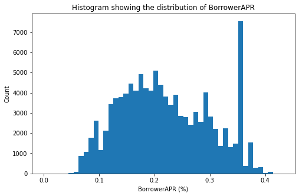

```python
#standard-scaled plot
binsize = 0.009
bins = np.arange(0, df['BorrowerAPR'].max()+binsize, binsize)

plt.figure(figsize=[8, 5])
plt.hist(data = df, x = 'BorrowerAPR', bins = bins)
plt.xlabel('BorrowerAPR (%)')
plt.ylabel('Count')
plt.title('Histogram showing the distribution of BorrowerAPR')
plt.show()
```

> BorrowerAPR has 3 peaks (multimodal Distribution) This is observed between the regions:
> - Between 0.15 and 0.2
> - At 0.3
> - Between 0.35 and 0.4

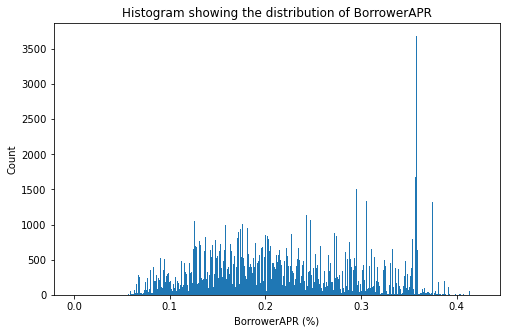

```python
binsize = 0.001
bins = np.arange(0, df['BorrowerAPR'].max()+binsize, binsize)

plt.figure(figsize=[8, 5])
plt.hist(data = df, x = 'BorrowerAPR', bins = bins)
plt.xlabel('BorrowerAPR (%)')
plt.ylabel('Count')
plt.title('Histogram showing the distribution of BorrowerAPR')
plt.show()
```

> BorrowerAPR has 3 peaks (multimodal Distribution) This is observed between the regions:
> - Between 0.15 and 0.2
> - At 0.3
> - Between 0.35 and 0.4

> Other regions remain to be evenly distributed.

```python
df['BorrowerAPR'].value_counts()
```

```
0.35797    3671
0.35643    1644
0.37453    1259
0.30532     902
0.29510     747
           ...
0.23859       1
0.13070       1
0.23078       1
0.29101       1
0.19543       1
Name: BorrowerAPR, Length: 5993, dtype: int64
```

#### Histogram showing the distribution of Borrower Rate

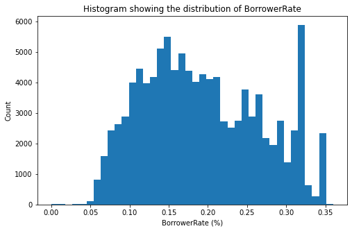

```python
#standard-scaled plot
binsize = 0.009
bins = np.arange(0, df['BorrowerRate'].max()+binsize, binsize)

plt.figure(figsize=[8, 5])
plt.hist(data = df, x = 'BorrowerRate', bins = bins)
plt.xlabel('BorrowerRate (%)')
plt.ylabel('Count')
plt.title('Histogram showing the distribution of BorrowerRate')
plt.show()
```

> Borrower Interest Rate has a Multimodal Distribution almost similar to that of the BorrowerAPR. This indicates that there is a relationship between this two variables.

```python
df['BorrowerRate'].value_counts()
```

```
0.3177    3671
0.3500    1896
0.3199    1651
0.2699    1316
0.1099     949
          ...
0.2648       1
0.2719       1
0.0791       1
0.0963       1
0.2309       1
Name: BorrowerRate, Length: 2218, dtype: int64
```

#### Histogram showing the distribution of Original loan amount (LoanOriginalAmount)

```python
df['LoanOriginalAmount'].value_counts()
```

```
4000     14066
15000    12254
10000    10798
5000      6361
2000      5675
         ...
3718         1
12609        1
3061         1
17574        1
4292         1
Name: LoanOriginalAmount, Length: 2340, dtype: int64
```

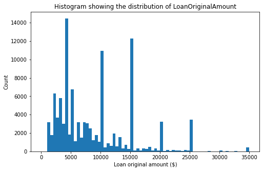

```python
binsize = 500
bins = np.arange(0, df['LoanOriginalAmount'].max()+binsize, binsize)

plt.figure(figsize=[8, 5])
plt.hist(data = df, x = 'LoanOriginalAmount', bins = bins)
plt.xlabel('Loan original amount ($)')
plt.ylabel('Count')
plt.title('Histogram showing the distribution of LoanOriginalAmount')
plt.show()
```

#### Countplot showing the distribution of Employment Status (EmploymentStatus)

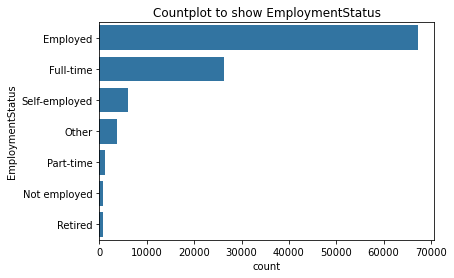

```python
#Countplot to show EmploymentStatus

type_order = df['EmploymentStatus'].value_counts().index
sb.countplot(data=df, y='EmploymentStatus', color=base_color,
             order=type_order).set_title('Countplot to show EmploymentStatus');
#plt.title('Barchart showing the distribution of EmploymentStatus')
```

> From the Countplot it shows that a large number of Employed people rely on Loans compared to a small count who are retired.

```python
df['EmploymentStatus'].value_counts()
```

```
Employed         67321
Full-time        26342
Self-employed     6132
Other             3800
Part-time         1088
Not employed       834
Retired            795
Name: EmploymentStatus, dtype: int64
```

#### Countplot showing the distribution of Loan Status (LoanStatus)

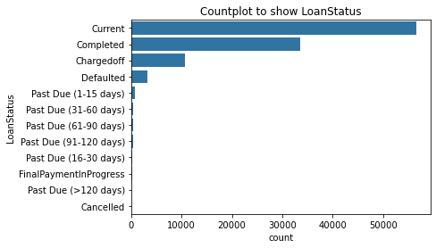

```python
#Countplot to show Loan Status
type_order = df['LoanStatus'].value_counts().index
sb.countplot(data=df, y='LoanStatus', color=base_color,
             order=type_order).set_title('Countplot to show LoanStatus');
```

> More borrowers in the Current Status. Very small number in Cancelled.

#### Pie Chart showing Distribution of Loan

```python
df.Term.value_counts()
```

```
36    80155
60    24543
12     1614
Name: Term, dtype: int64
```

> Distribution is into 3 parts (12 months, 36 months and 60 months)

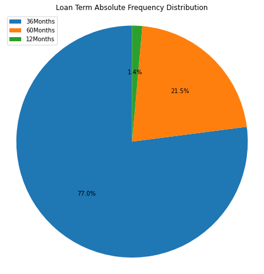

```python
plt.figure(figsize=[8,8])
period = loan.Term.value_counts()
labels = '36Months','60Months','12Months'
plt.pie(period, autopct='%1.1f%%', startangle=90)
plt.title('Loan Term Absolute Frequency Distribution')
plt.axis('square')
plt.legend(labels);
```

> More loans prefered with a term of 36months than 12 or 60 months

#### Countplot Showing various listing Categories

```python
#Count for each listing Category

df.ListingCategory.value_counts()
```

```
Debt Consolidation    58293
Other                 10491
Not Available          9363
Home Improvement       7432
Business               7187
Auto                   2572
Personal Loan          2395
Household Expenses     1995
Medical/Dental         1522
Taxes                   885
Large Purchases         876
Wedding Loans           770
Vacation                768
Student Use             756
Motorcycle              304
Engagement Ring         217
Baby&Adoption           199
Cosmetic Procedure       91
Boat                     85
Green Loans              59
RV                       52
Name: ListingCategory, dtype: int64
```

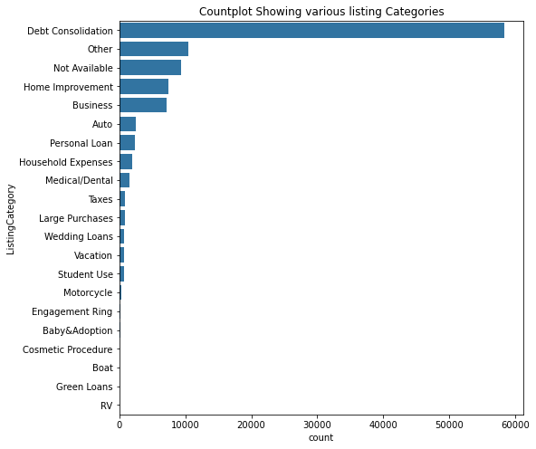

```python
#Countplot Showing various listing Categories

plt.figure(figsize=[8,8])
categories = df.ListingCategory.value_counts().index
sb.countplot(data = df, y = 'ListingCategory', color=base_color,
             order = categories).set_title('Countplot Showing various listing Categories');
```

> Debt Consolidation appears to have a larger listing compared to other listings. We will compare this variable (ListingCategory) with other variables of interests to dig deeper and have more understanding at the loans.

#### Creating a Countplot for IncomeRange

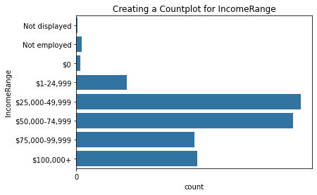

```python
#using barchart_y function created above
sb.countplot().set_title('Creating a Countplot for IncomeRange');
barchart_y('IncomeRange')
```

> From the income range bar chart: borrowers earning between 25000-49000 and between 50000-74999 were likely to have a loan.

#### Creating a Countplot for Employment Status

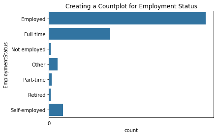

```python
sb.countplot().set_title('Creating a Countplot for Employment Status');
barchart_y('EmploymentStatus')
```

> Those who were employed were high likely to borrow a loan.

> Can employment status determine the loan amount? We shall see further into this later

#### Pie chart for Home Ownership

```python
#Checking number of parameters and value count for each

count = df.IsBorrowerHomeowner.value_counts()
print(count)
```

```
True     54905
False    51407
Name: IsBorrowerHomeowner, dtype: int64
```

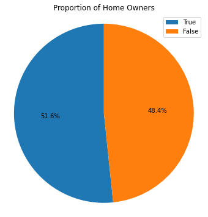

```python
plt.figure(figsize=[8,6])
labels=count.index
plt.pie(count, autopct='%1.1f%%', startangle=90)
plt.axis('square')
plt.title('Proportion of Home Owners')
plt.legend(labels);
```

> 51.6% of home owners are loan borrowers compared to 48.4% who don't own a home. This small margin means that this variable is not a good determinant to tell whether those who are loan borrowers home owners or not.

#### Barchart for LoanOriginationDate

For LoanOriginationDate we need to split this data in months and years for easier analysis. Will intorduce two more variables (one for the month and another for year. The variables include:

- loanOrigination_month
- loanOrigination_year

```python
# Slitting the variable then introducing month and year

df['loanOrigination_month'] = df['LoanOriginationDate'].dt.month
df['loanOrigination_year'] = df['LoanOriginationDate'].dt.year
```

```python
#confirm split

df.info()
```

```
<class 'pandas.core.frame.DataFrame'>
Int64Index: 106312 entries, 0 to 113936
Data columns (total 19 columns):
 #   Column                    Non-Null Count   Dtype
---  ------                    --------------   -----
 0   ListingCreationDate       106312 non-null  datetime64[ns]
 1   Term                      106312 non-null  int64
 2   LoanStatus                106312 non-null  category
 3   BorrowerAPR               106312 non-null  float64
 4   BorrowerRate              106312 non-null  float64
 5   LenderYield               106312 non-null  float64
 6   ListingCategory           106312 non-null  category
 7   EmploymentStatus          106312 non-null  category
 8   EmploymentStatusDuration  106312 non-null  int64
 9   IsBorrowerHomeowner       106312 non-null  bool
 10  IncomeRange               106312 non-null  category
 11  IncomeVerifiable          106312 non-null  bool
 12  StatedMonthlyIncome       106312 non-null  float64
 13  LoanOriginalAmount        106312 non-null  int64
 14  LoanOriginationDate       106312 non-null  datetime64[ns]
 15  LoanOriginationQuarter    106312 non-null  category
 16  MonthlyLoanPayment        106312 non-null  float64
 17  loanOrigination_month     106312 non-null  int64
 18  loanOrigination_year      106312 non-null  int64
dtypes: bool(2), category(5), datetime64[ns](2), float64(5), int64(5)
memory usage: 11.3 MB
```

```python
#check sample data

df.head(5)
```

|  | ListingCreationDate | Term | LoanStatus | BorrowerAPR | BorrowerRate | LenderYield | ListingCategory | EmploymentStatus | EmploymentStatusDuration | IsBorrowerHomeowner | IncomeRange | IncomeVerifiable | StatedMonthlyIncome | LoanOriginalAmount | LoanOriginationDate | LoanOriginationQuarter | MonthlyLoanPayment | loanOrigination_month | loanOrigination_year |
| --- | --- | --- | --- | --- | --- | --- | --- | --- | --- | --- | --- | --- | --- | --- | --- | --- | --- | --- | --- |
| 0 | 2007-08-26 19:09:29.263 | 36 | Completed | 0.16516 | 0.1580 | 0.1380 | Not Available | Self-employed | 2 | True | $25,000-49,999 | True | 3083.333333 | 9425 | 2007-09-12 | Q3 2007 | 330.43 | 9 | 2007 |
| 1 | 2014-02-27 08:28:07.900 | 36 | Current | 0.12016 | 0.0920 | 0.0820 | Home Improvement | Employed | 44 | False | $50,000-74,999 | True | 6125.000000 | 10000 | 2014-03-03 | Q1 2014 | 318.93 | 3 | 2014 |
| 3 | 2012-10-22 11:02:35.010 | 36 | Current | 0.12528 | 0.0974 | 0.0874 | Motorcycle | Employed | 113 | True | $25,000-49,999 | True | 2875.000000 | 10000 | 2012-11-01 | Q4 2012 | 321.45 | 11 | 2012 |
| 4 | 2013-09-14 18:38:39.097 | 36 | Current | 0.24614 | 0.2085 | 0.1985 | Home Improvement | Employed | 44 | True | $100,000+ | True | 9583.333333 | 15000 | 2013-09-20 | Q3 2013 | 563.97 | 9 | 2013 |
| 5 | 2013-12-14 08:26:37.093 | 60 | Current | 0.15425 | 0.1314 | 0.1214 | Debt Consolidation | Employed | 82 | True | $100,000+ | True | 8333.333333 | 15000 | 2013-12-24 | Q4 2013 | 342.37 | 12 | 2013 |

```
2013    34337
2012    19549
2014    12172
2008    11548
2011    11228
2007     9786
2010     5645
2009     2047
Name: loanOrigination_year, dtype: int64
```

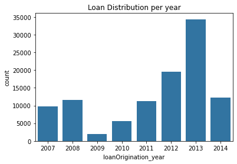

```python
#Loan Distribution per year
loan_year = df['loanOrigination_year'].value_counts()

print(loan_year)

#Barchart showing Loan Origination per year using function created (barchart_x)
sb.countplot().set_title('Loan Distribution per year');
barchart_x('loanOrigination_year')
```

- Loan borrowers were lowest in 2009, what could have been the issue?
- Loan borrowers highest in 2012 and 2013

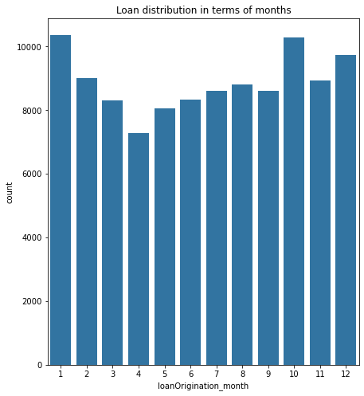

```python
#Loan distribution in terms of months

plt.figure(figsize=[7,8])
sb.countplot().set_title('Loan distribution in terms of months');
barchart_x('loanOrigination_month')
```

```python
#Counts per
quarter = df['LoanOriginationQuarter'].value_counts()

print(quarter)
```

```
Q4 2013    14450
Q1 2014    12172
Q3 2013     9173
Q2 2013     7099
Q3 2012     5631
Q2 2012     5061
Q1 2012     4433
Q4 2012     4424
Q2 2008     4344
Q4 2011     3913
Q1 2013     3615
Q3 2008     3602
Q2 2007     3118
Q3 2011     3093
Q1 2008     3074
Q3 2007     2671
Q4 2007     2592
Q2 2011     2478
Q1 2011     1744
Q4 2010     1599
Q2 2010     1534
Q4 2009     1449
Q1 2007     1405
Q3 2010     1270
Q1 2010     1242
Q3 2009      585
Q4 2008      528
Q2 2009       13
Name: LoanOriginationQuarter, dtype: int64
```

> LoanOriginationQuarter categorical variable output is unordered. Need to order the output

```python
#Ordering the LoanOriginationQuarter categorical variable
unordered_quarter = ['Q1 2007', 'Q2 2007', 'Q3 2007', 'Q4 2007', 'Q1 2008', 'Q2 2008', 'Q3 2008', 'Q4 2008',
       'Q1 2009', 'Q2 2009', 'Q3 2009', 'Q4 2009', 'Q1 2010', 'Q2 2010', 'Q3 2010', 'Q4 2010',
       'Q1 2011', 'Q2 2011', 'Q3 2011', 'Q4 2011', 'Q1 2012', 'Q2 2012', 'Q3 2012', 'Q4 2012',
       'Q1 2013', 'Q2 2013', 'Q3 2013', 'Q4 2013', 'Q1 2014']
ordered_quarter = CategoricalDtype(categories=unordered_quarter, ordered=True)
df.LoanOriginationQuarter = df.LoanOriginationQuarter.astype(ordered_quarter)
```

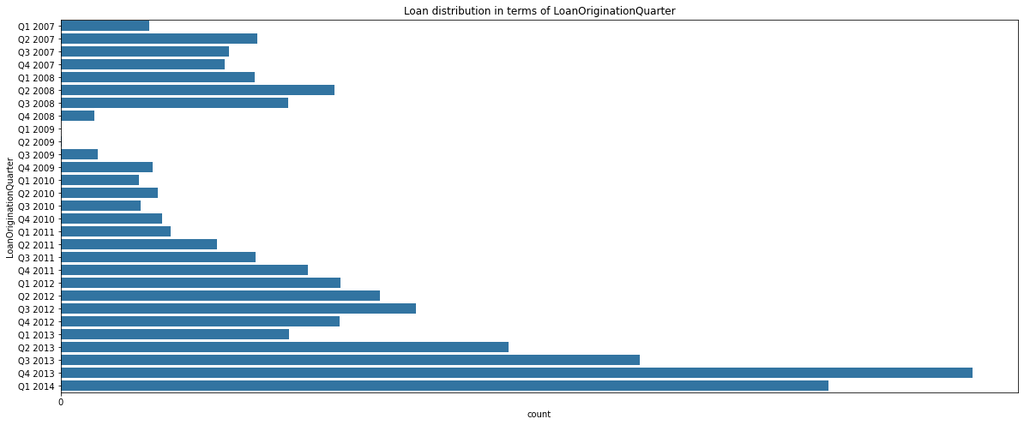

```python
#plotting the ordered LoanOriginationQuarter in barchart_y function created

plt.figure(figsize=[20,8])
sb.countplot().set_title('Loan distribution in terms of LoanOriginationQuarter');
barchart_y('LoanOriginationQuarter')
```

> More loan borrowers in 2013 as compared to other year. 2009 had the lowest loan borrowers. What could be the factors affecting 2009 and 2013?

### Discuss the distribution(s) of your variable(s) of interest. Were there any unusual points? Did you need to perform any transformations?

> - BorrowerRate: Has a multimodal distribution with several peaks e.g. at 0.15, 0.2, 0.25, 0.3, 0.35.
> - BorrowerAPR: Has also a multimodal distribution with similar peaks like the BorrowerRate.

This indicates that there is a relationship between BorrowerRate and BorrowerAPR.

> - LoanOriginalAmount: Multimodal distribution with various peaks. The peaks are at 5000, 10000, 15000, 20000, 25000 and 35000. However, it can be observed low loan amounts were awarded to a huge number of borrowers as compared to a huge sum of 35000.
> - IsBorrowerHomeowner: 51.6% of home owners are loan borrowers compared to 48.4% who don't own a home. This small margin means that this variable is not a good determinant to tell whether those who are loan borrowers home owners or not.
> - LoanStatus: Current status has a huge count as compared to the lowest which is cancelled (neglibible). Will focus more on the Completed, Defaulted and PastDue in the analysis.

### Of the features you investigated, were there any unusual distributions? Did you perform any operations on the data to tidy, adjust, or change the form of the data? If so, why did you do this?

> - LoanOriginationDate: Split this variable into loanOrigination_year and loanOrigination_month so as to help in analysis. This so as to be able to tell which year or month did we have normal/abnormal trends and would require further investigation.
> - Very low number of borrowers in 2009 was observed which was unusual and very high in 2012 and 2013.
> - Ordering of categorical variable LoanOriginationQuarter for easier visibility when plotting.
> - Changing of bins size to make the graphs visible.

## Bivariate Exploration

> Will investigate relationships between other variables BorrowerAPR and BorrowerRate

```python
#check data types
df.info()
```

```
<class 'pandas.core.frame.DataFrame'>
Int64Index: 106312 entries, 0 to 113936
Data columns (total 19 columns):
 #   Column                    Non-Null Count   Dtype
---  ------                    --------------   -----
 0   ListingCreationDate       106312 non-null  datetime64[ns]
 1   Term                      106312 non-null  int64
 2   LoanStatus                106312 non-null  category
 3   BorrowerAPR               106312 non-null  float64
 4   BorrowerRate              106312 non-null  float64
 5   LenderYield               106312 non-null  float64
 6   ListingCategory           106312 non-null  category
 7   EmploymentStatus          106312 non-null  category
 8   EmploymentStatusDuration  106312 non-null  int64
 9   IsBorrowerHomeowner       106312 non-null  bool
 10  IncomeRange               106312 non-null  category
 11  IncomeVerifiable          106312 non-null  bool
 12  StatedMonthlyIncome       106312 non-null  float64
 13  LoanOriginalAmount        106312 non-null  int64
 14  LoanOriginationDate       106312 non-null  datetime64[ns]
 15  LoanOriginationQuarter    106312 non-null  category
 16  MonthlyLoanPayment        106312 non-null  float64
 17  loanOrigination_month     106312 non-null  int64
 18  loanOrigination_year      106312 non-null  int64
dtypes: bool(2), category(5), datetime64[ns](2), float64(5), int64(5)
memory usage: 11.3 MB
```

```python
#Listing of numerical variables
num_vars = ['Term','BorrowerAPR','BorrowerRate','LenderYield','LoanOriginalAmount',
            'StatedMonthlyIncome','MonthlyLoanPayment','EmploymentStatusDuration']
```

##### Correlation of numerical variable using heat map

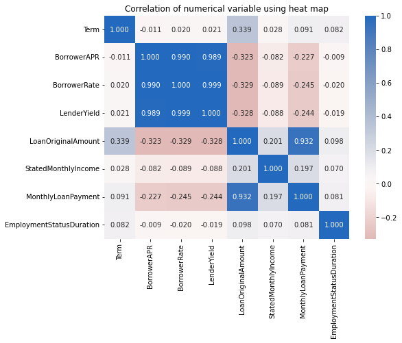

```python
#Correlation plot
plt.figure(figsize = [8, 6])
sb.heatmap(loan[num_vars].corr(), annot = True, fmt = '.3f',
           cmap = 'vlag_r', center = 0)
plt.title('Correlation of numerical variable using heat map');
plt.show()
```

> - BorrowerAPR is highly correlated with BorrowerRate.
> - When BorrowerAPR increases, BorrowerRate increases and vice versa is true.
> - There is a negative correlation between LoanOriginalAmount vs BorrowerRate/BorrowerAPR.

```python
#Sample random 500 loans so that plots are clearer.
np.random.seed(1)
df_sample = df.sample(500)
```

#### Plotting LoanOriginalAmount, Term vs BorrowerAPR

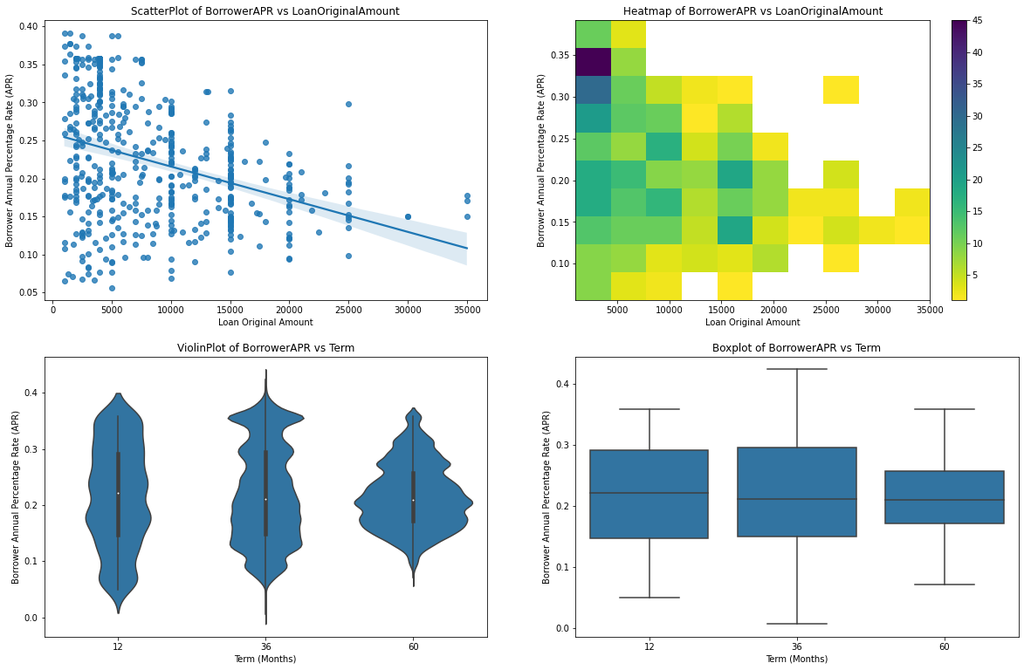

```python
# LoanOriginalAmount, Term vs BorrowerAPR

plt.figure(figsize=[20,13])

#Creating ScatterPlot for LoanOriginalAmount, BorrowerAPR
plt.subplot(2,2,1)
sb.regplot(data=df_sample, y='BorrowerAPR', x='LoanOriginalAmount')
plt.ylabel('Borrower Annual Percentage Rate (APR)')
plt.xlabel('Loan Original Amount')
plt.title('ScatterPlot of BorrowerAPR vs LoanOriginalAmount');

#Creating Heatmap for LoanOriginalAmount, BorrowerAPR
plt.subplot(2,2,2)
plt.hist2d(data=df_sample,  y='BorrowerAPR', x='LoanOriginalAmount', cmap='viridis_r', cmin=0.5)
plt.ylabel('Borrower Annual Percentage Rate (APR)')
plt.xlabel('Loan Original Amount')
plt.title('Heatmap of BorrowerAPR vs LoanOriginalAmount');
plt.colorbar();

#Creating Violin plot for Term, BorrowerAPR
plt.subplot(2,2,3)
sb.violinplot(data=df, y='BorrowerAPR', x='Term',color=base_color)
plt.ylabel('Borrower Annual Percentage Rate (APR)')
plt.xlabel('Term (Months)')
plt.title('ViolinPlot of BorrowerAPR vs Term');

#Creating Boxplot for Term, BorrowerAPR
plt.subplot(2,2,4)
sb.boxplot(data=df,  y='BorrowerAPR', x='Term', color=base_color)
plt.ylabel('Borrower Annual Percentage Rate (APR)')
plt.xlabel('Term (Months)')
plt.title('Boxplot of BorrowerAPR vs Term');
```

#### Plotting LoanOriginalAmount, Term vs BorrowerRate

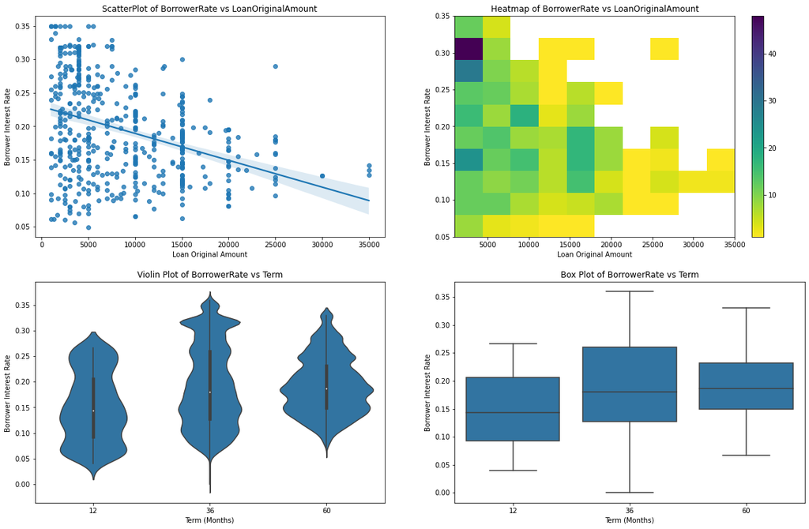

```python
plt.figure(figsize=[20,13])

#Creating ScatterPlot for LoanOriginalAmount, BorrowerRate
plt.subplot(2,2,1)
sb.regplot(data=df_sample, y='BorrowerRate', x='LoanOriginalAmount')
plt.ylabel('Borrower Interest Rate')
plt.xlabel('Loan Original Amount')
plt.title('ScatterPlot of BorrowerRate vs LoanOriginalAmount');

#Creating Heatmap for LoanOriginalAmount, BorrowerRate
plt.subplot(2,2,2)
plt.hist2d(data=df_sample,  y='BorrowerRate', x='LoanOriginalAmount', cmap='viridis_r', cmin=0.5)
plt.ylabel('Borrower Interest Rate')
plt.xlabel('Loan Original Amount')
plt.title('Heatmap of BorrowerRate vs LoanOriginalAmount');
plt.colorbar();

#Creating Violin plot for Term, BorrowerRate
plt.subplot(2,2,3)
sb.violinplot(data=df, y='BorrowerRate', x='Term',color=base_color)
plt.ylabel('Borrower Interest Rate ')
plt.xlabel('Term (Months)')
plt.title('Violin Plot of BorrowerRate vs Term');

#Creating Boxplot for Term, BorrowerRate
plt.subplot(2,2,4)
sb.boxplot(data=df,  y='BorrowerRate', x='Term',color=base_color)
plt.ylabel('Borrower Interest Rate')
plt.xlabel('Term (Months)')
plt.title('Box Plot of BorrowerRate vs Term');
```

#### Term vs BorroweAPR

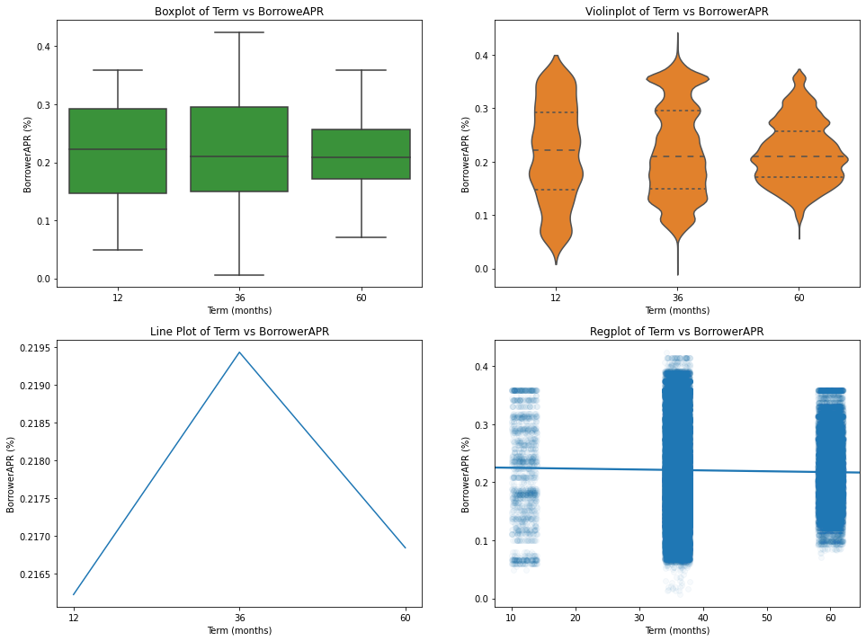

```python
plt.figure(figsize=(16,12))
# Plotting boxplot.
plt.subplot(2,2,1)

sb.boxplot(x='Term',y='BorrowerAPR',data=df,color=base_c2)
plt.xlabel('Term (months)')
plt.ylabel('BorrowerAPR (%)')
plt.title('Boxplot of Term vs BorroweAPR')
# Plotting violinplot.
plt.subplot(2,2,2)
sb.violinplot(x='Term',y='BorrowerAPR',data=df,color=base_c1,inner='quartile')
plt.xlabel('Term (months)')
plt.ylabel('BorrowerAPR (%)')
plt.title('Violinplot of Term vs BorrowerAPR');

# Plotting a Line plot
plt.subplot(2,2,3)
plt.plot(loan.groupby('Term')['BorrowerAPR'].mean())
plt.xlabel('Term (months)')
plt.ylabel('BorrowerAPR (%)')
plt.xticks([12,36,60])
plt.title('Line Plot of Term vs BorrowerAPR');

#Plotting a Regplot
plt.subplot(2,2,4)
sb.regplot(data = df, x = 'Term', y = 'BorrowerAPR', truncate=False, x_jitter=2,scatter_kws={'alpha':1/30})
plt.xlabel('Term (months)')
plt.ylabel('BorrowerAPR (%)')
plt.title('Regplot of Term vs BorrowerAPR');
plt.show();
```

#### BorrowerAPR vs LoanOriginalAmount Analysis

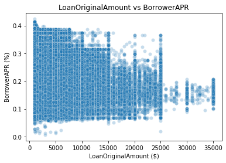

```python
#Scatter plot.
sb.scatterplot(x='LoanOriginalAmount',y='BorrowerAPR',data=df, x_jitter=0.3,alpha=1/4)
plt.xlabel('LoanOriginalAmount ($)')
plt.ylabel('BorrowerAPR (%)')
plt.title('LoanOriginalAmount vs BorrowerAPR');
```

Observations:

- There is gradual decrease in BorrowerAPR against the LoanOriginalAmount. Though not clear enough. We will analyse further below.

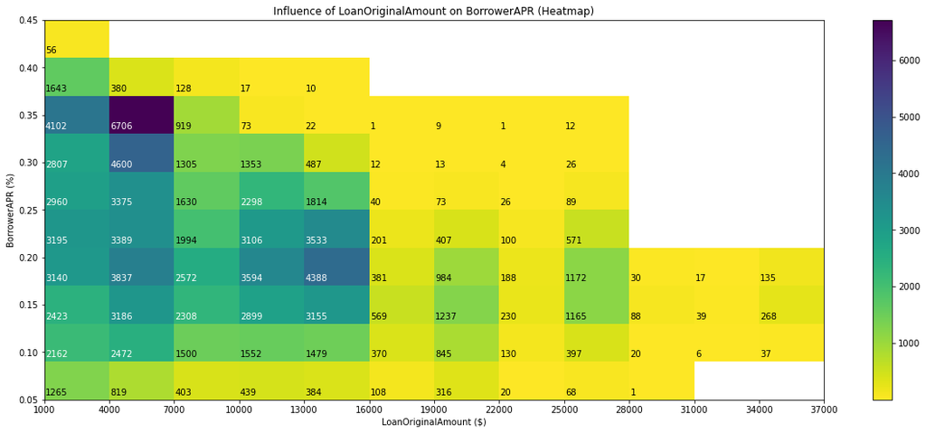

```python
#Plotting Influence of LoanOriginalAmount on BorrowerAPR (Heatmap)
plt.figure(figsize=(20,8))
bins_x = np.arange(1000,35000+5000,3000)
bins_y=np.arange(0.05,0.40+0.06,0.04)
labels = ['{}'.format(x) for x in bins_x]
gt = plt.hist2d(y='BorrowerAPR',x='LoanOriginalAmount',data=df,cmin=0.5,cmap='viridis_r',bins=[bins_x,bins_y])
count = gt[0]
for i in range(count.shape[0]):
    for j in range(count.shape[1]):
        annot = count[i,j]
        if annot!=np.nan and annot >= 2000:
            plt.text(x=gt[1][i]+50,y=gt[2][j]+0.005,s=int(annot),color='white')
        elif annot !=np.nan and annot > 0:
             plt.text(x=gt[1][i]+50,y=gt[2][j]+0.005,s=int(annot),color='black')
plt.colorbar()
plt.xticks(bins_x,labels)
plt.title('Influence of LoanOriginalAmount on BorrowerAPR (Heatmap)')
plt.xlabel('LoanOriginalAmount ($)')
plt.ylabel('BorrowerAPR (%)');
```

Observations:

- BorrowerAPR count highest between 1000 and 7000.
- We have a negative correlation between BorrowerAPR and LoanOriginalAmount. As LoanOriginalAmount increases, BorrowerAPR is decreasing and BorrowerAPR count is decreasing significantly after 16,000.
- When LoanOriginalAmount between 1000 - 7000 highest count of BorrowerAPR is 6706 at approximately 0.35.

It can be noted that when LoanOriginalAmount is small it has more borrowers and very high BorrowerAPR, What causes this?

##### Comparison between EmploymentStatus, LoanOriginalAmount and IncomeRange

```python
df.groupby('IncomeRange')['LoanOriginalAmount'].mean()
```

```
IncomeRange
Not displayed      7208.985612
Not employed       4882.822360
$0                 7410.930757
$1-24,999          4274.599147
$25,000-49,999     6178.294814
$50,000-74,999     8675.889479
$75,000-99,999    10365.375783
$100,000+         13072.880351
Name: LoanOriginalAmount, dtype: float64
```

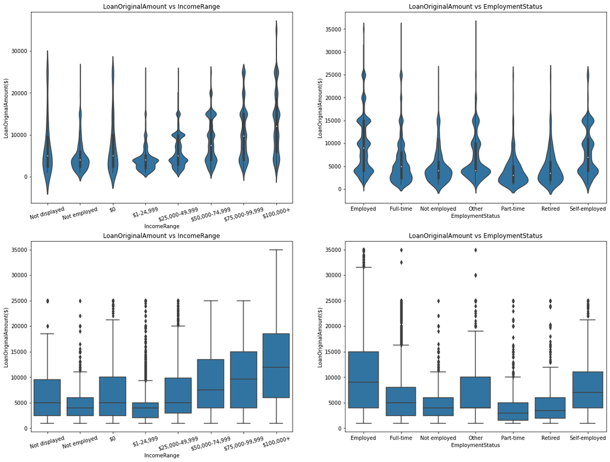

```python
#Violinplot for LoanOriginalAmount vs IncomeRange
plt.figure(figsize=[20,15])
plt.subplot(2,2,1)
sb.violinplot(data=df, y='LoanOriginalAmount', x='IncomeRange', color=base_color)
plt.ylabel('LoanOriginalAmount($)')
plt.title('LoanOriginalAmount vs IncomeRange')
plt.xticks(rotation=15);

#Violinplot for LoanOriginalAmount vs EmploymentStatus
plt.subplot(2,2,2)
sb.violinplot(data=df, y='LoanOriginalAmount', x='EmploymentStatus', color=base_color)
plt.ylabel('LoanOriginalAmount($)')
plt.title('LoanOriginalAmount vs EmploymentStatus');

#Boxplot for LoanOriginalAmount vs IncomeRange
plt.subplot(2,2,3)
sb.boxplot(data=df, y='LoanOriginalAmount', x='IncomeRange', color=base_color)
plt.ylabel('LoanOriginalAmount($)')
plt.title('LoanOriginalAmount vs IncomeRange')
plt.xticks(rotation=15);

#Boxplot for LoanOriginalAmount vs EmploymentStatus
plt.subplot(2,2,4)
sb.boxplot(data=df, y='LoanOriginalAmount', x='EmploymentStatus', color=base_color)
plt.ylabel('LoanOriginalAmount($)')
plt.title('LoanOriginalAmount vs EmploymentStatus');
```

Observations:

```python
df.info()
```

```
<class 'pandas.core.frame.DataFrame'>
Int64Index: 106312 entries, 0 to 113936
Data columns (total 19 columns):
 #   Column                    Non-Null Count   Dtype
---  ------                    --------------   -----
 0   ListingCreationDate       106312 non-null  datetime64[ns]
 1   Term                      106312 non-null  int64
 2   LoanStatus                106312 non-null  category
 3   BorrowerAPR               106312 non-null  float64
 4   BorrowerRate              106312 non-null  float64
 5   LenderYield               106312 non-null  float64
 6   ListingCategory           106312 non-null  category
 7   EmploymentStatus          106312 non-null  category
 8   EmploymentStatusDuration  106312 non-null  int64
 9   IsBorrowerHomeowner       106312 non-null  bool
 10  IncomeRange               106312 non-null  category
 11  IncomeVerifiable          106312 non-null  bool
 12  StatedMonthlyIncome       106312 non-null  float64
 13  LoanOriginalAmount        106312 non-null  int64
 14  LoanOriginationDate       106312 non-null  datetime64[ns]
 15  LoanOriginationQuarter    106312 non-null  category
 16  MonthlyLoanPayment        106312 non-null  float64
 17  loanOrigination_month     106312 non-null  int64
 18  loanOrigination_year      106312 non-null  int64
dtypes: bool(2), category(5), datetime64[ns](2), float64(5), int64(5)
memory usage: 15.3 MB
```

```python
df.value_counts('LoanStatus')
```

```
LoanStatus
Current                   56566
Completed                 33548
Chargedoff                10634
Defaulted                  3291
Past Due (1-15 days)        806
Past Due (31-60 days)       363
Past Due (61-90 days)       313
Past Due (91-120 days)      304
Past Due (16-30 days)       265
FinalPaymentInProgress      205
Past Due (>120 days)         16
Cancelled                     1
dtype: int64
```

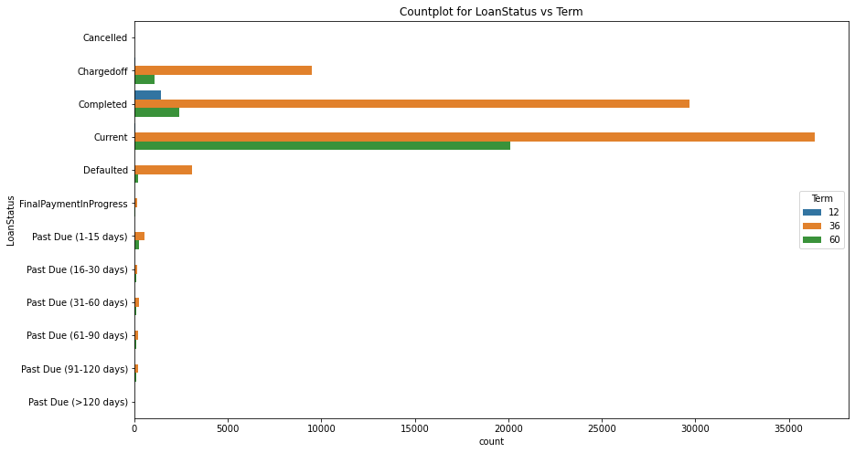

```python
#Countplot for LoanStatus vs Term

plt.figure(figsize=[14,8])
sb.countplot(data=df, y='LoanStatus', hue='Term').set_title('Countplot for LoanStatus vs Term');
```

Observation:

- Completed Status: High count of Loans with Term of 36months fall in this category compared to a small count in 12month term.
- Defaulted: Most of the loans defaulted fall in the Term of 36months.
- Past Due: Small counts fall in the due category but mostly loan in the Term of 36months.
- FinalPaymentInProgress - Small count which lies in the Term of 36months.

```python
#Mean for LoanOriginalAmount against LoanStatus
df.groupby('LoanStatus')['LoanOriginalAmount'].mean()
```

```
LoanStatus
Cancelled                  1000.000000
Chargedoff                 6546.651495
Completed                  6333.172141
Current                   10360.854612
Defaulted                  7225.416287
FinalPaymentInProgress     8346.121951
Past Due (1-15 days)       8468.445409
Past Due (16-30 days)      8156.430189
Past Due (31-60 days)      8534.336088
Past Due (61-90 days)      7730.019169
Past Due (91-120 days)     8003.976974
Past Due (>120 days)       8281.250000
Name: LoanOriginalAmount, dtype: float64
```

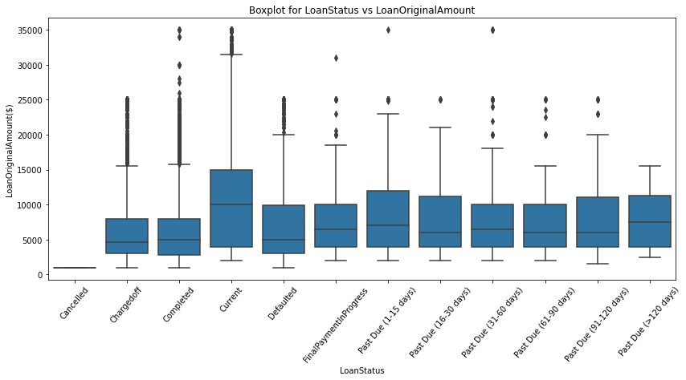

```python
#Boxplot for LoanStatus vs LoanOriginalAmount
plt.figure(figsize=[14,6])
sb.boxplot(data=df, x='LoanStatus', y='LoanOriginalAmount',
           color=base_color).set_title('Boxplot for LoanStatus vs LoanOriginalAmount')
plt.ylabel('LoanOriginalAmount($)')
plt.xticks(rotation=50);
```

Observations:

- Completed: Mean for LoanOriginalAmount was around 6300.
- Defaulted: Mean for LoanOriginalAmount was around 7200.
- Current: Mean for LoanOriginalAmount was around 10360.

### Did you observe any interesting relationships between the other features (not the main feature(s) of interest)?

> - Some borrowers from the IncomeRange which is 0, had high LoanOriginalAmount mean than those in 1-24,999 category.

## Multivariate Exploration

> Will analyse more variables to check on the relationships.

```python
df.head()
```

|  | ListingCreationDate | Term | LoanStatus | BorrowerAPR | BorrowerRate | LenderYield | ListingCategory | EmploymentStatus | EmploymentStatusDuration | IsBorrowerHomeowner | IncomeRange | IncomeVerifiable | StatedMonthlyIncome | LoanOriginalAmount | LoanOriginationDate | LoanOriginationQuarter | MonthlyLoanPayment | loanOrigination_month | loanOrigination_year |
| --- | --- | --- | --- | --- | --- | --- | --- | --- | --- | --- | --- | --- | --- | --- | --- | --- | --- | --- | --- |
| 0 | 2007-08-26 19:09:29.263 | 36 | Completed | 0.16516 | 0.1580 | 0.1380 | Not Available | Self-employed | 2 | True | $25,000-49,999 | True | 3083.333333 | 9425 | 2007-09-12 | Q3 2007 | 330.43 | 9 | 2007 |
| 1 | 2014-02-27 08:28:07.900 | 36 | Current | 0.12016 | 0.0920 | 0.0820 | Home Improvement | Employed | 44 | False | $50,000-74,999 | True | 6125.000000 | 10000 | 2014-03-03 | Q1 2014 | 318.93 | 3 | 2014 |
| 3 | 2012-10-22 11:02:35.010 | 36 | Current | 0.12528 | 0.0974 | 0.0874 | Motorcycle | Employed | 113 | True | $25,000-49,999 | True | 2875.000000 | 10000 | 2012-11-01 | Q4 2012 | 321.45 | 11 | 2012 |
| 4 | 2013-09-14 18:38:39.097 | 36 | Current | 0.24614 | 0.2085 | 0.1985 | Home Improvement | Employed | 44 | True | $100,000+ | True | 9583.333333 | 15000 | 2013-09-20 | Q3 2013 | 563.97 | 9 | 2013 |
| 5 | 2013-12-14 08:26:37.093 | 60 | Current | 0.15425 | 0.1314 | 0.1214 | Debt Consolidation | Employed | 82 | True | $100,000+ | True | 8333.333333 | 15000 | 2013-12-24 | Q4 2013 | 342.37 | 12 | 2013 |

##### Relationship betweem BorrowerAPR, LoanStatus, Term

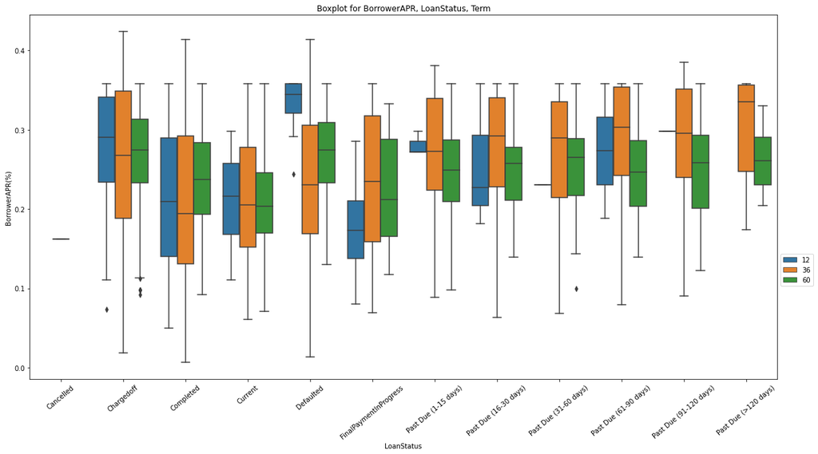

```python
#Boxplot for BorrowerAPR, LoanStatus, Term
plt.figure(figsize=[20,10])
sb.boxplot(data = df, y = 'BorrowerAPR', x = 'LoanStatus',
           hue = 'Term').set_title('Boxplot for BorrowerAPR, LoanStatus, Term')
plt.legend(loc = 6, bbox_to_anchor = (1, 0.3))
plt.ylabel('BorrowerAPR(%)')
plt.xticks(rotation = 40);
```

##### BorrowerAPR, BorrowerRate, EmploymentStatus.

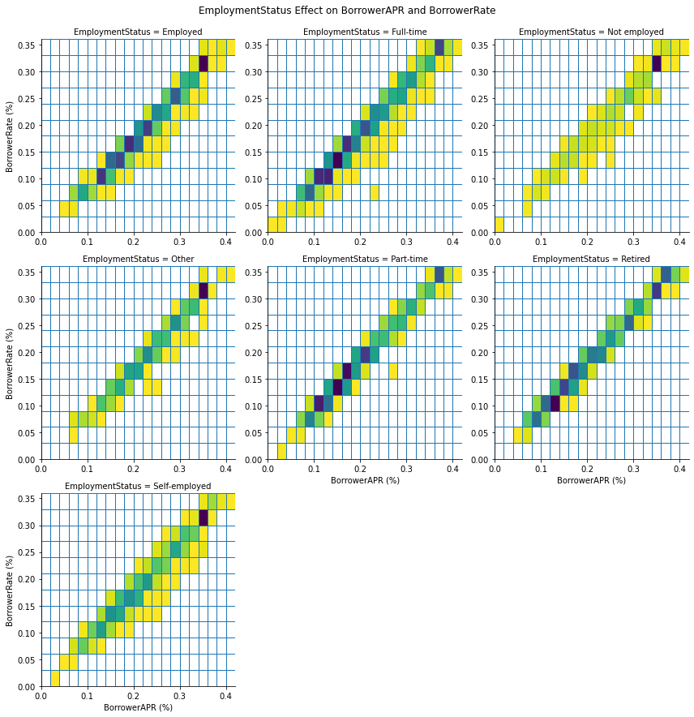

```python
#Heatmap for BorrowerAPR, BorrowerRate, EmploymentStatus.
bins_x = np.arange(0,df['BorrowerAPR'].max()+0.01,0.02)
bins_y = np.arange(0,df['BorrowerRate'].max()+0.01,0.03)
g = sb.FacetGrid(data = df, col = 'EmploymentStatus', sharex=False,sharey=False,col_wrap = 3, height = 4)
g.map(plt.hist2d, 'BorrowerAPR', 'BorrowerRate',bins=[bins_x,bins_y], cmap = 'viridis_r', cmin = 0.5)
g.set_xlabels('BorrowerAPR (%)')
g.set_ylabels('BorrowerRate (%)')

g.fig.suptitle('EmploymentStatus Effect on BorrowerAPR and BorrowerRate',y=1.02)
plt.show()
```

##### BorrowerAPR, Term, LoanOriginalAmount.

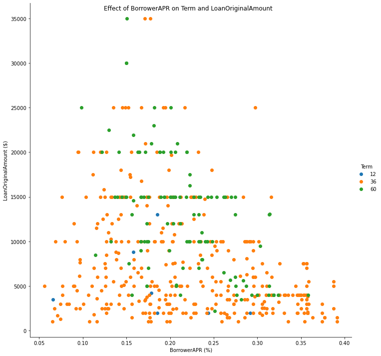

```python
#Plotting a Facet grid
#Using sample data to plot

g = sb.FacetGrid(data = df_sample, hue = 'Term', height = 10)
g.map(plt.scatter, 'BorrowerAPR', 'LoanOriginalAmount')
g.set_xlabels('BorrowerAPR (%)')
g.set_ylabels('LoanOriginalAmount ($)')
g.fig.suptitle('Effect of BorrowerAPR on Term and LoanOriginalAmount')
g.add_legend();
```

Observations:

- LoanOriginalAmount above 15000 have long Terms of 36 and 60 months.
- LoanOriginalAmount above 15000 have BorrowerAPR below 0.3.
- LoanOriginalAmount below 10000 have BorrowerAPR ranging between 0.05 to 0.4
- 12 months Term have low LoanOriginalAmount and low BorrowerAPR

### Were there any interesting or surprising interactions between features?

> How the 12month term had a very high BorrowerAPR compared to other loan Term for the Defaulted Status. Seems whenthe short period Term are Loans are Defaulted the BorrowerAPR increases significantly.

```python
df.info()
```

```
<class 'pandas.core.frame.DataFrame'>
Int64Index: 106312 entries, 0 to 113936
Data columns (total 19 columns):
 #   Column                    Non-Null Count   Dtype
---  ------                    --------------   -----
 0   ListingCreationDate       106312 non-null  datetime64[ns]
 1   Term                      106312 non-null  int64
 2   LoanStatus                106312 non-null  category
 3   BorrowerAPR               106312 non-null  float64
 4   BorrowerRate              106312 non-null  float64
 5   LenderYield               106312 non-null  float64
 6   ListingCategory           106312 non-null  category
 7   EmploymentStatus          106312 non-null  category
 8   EmploymentStatusDuration  106312 non-null  int64
 9   IsBorrowerHomeowner       106312 non-null  bool
 10  IncomeRange               106312 non-null  category
 11  IncomeVerifiable          106312 non-null  bool
 12  StatedMonthlyIncome       106312 non-null  float64
 13  LoanOriginalAmount        106312 non-null  int64
 14  LoanOriginationDate       106312 non-null  datetime64[ns]
 15  LoanOriginationQuarter    106312 non-null  category
 16  MonthlyLoanPayment        106312 non-null  float64
 17  loanOrigination_month     106312 non-null  int64
 18  loanOrigination_year      106312 non-null  int64
dtypes: bool(2), category(5), datetime64[ns](2), float64(5), int64(5)
memory usage: 11.3 MB
```

## Conclusions

Loan Data from Prosper data set contains 113,937 loans with 81 variables on each loan, including loan amount, borrower rate (or interest rate), current loan status, borrower income, and many others.

Some of the variables that I focused on are the LoanStatus, Term, BorrowerAPR, BorrowerRate will be of help in determining the APR for a borrower, factors affecting the the interest rate. Also to determine the loan status we will have to combine variables like LoanOriginalAmount, LoanStatus, EmploymentStatus, IsBorrowerHomeowner.

Some of the major questions that were identified to help in the visualization included:

- What factors affect the Borrower's interest rate for this loan?
- What factors affect the Borrower's Annual Percentage Rate (APR) for the loan?
- What are the factors affecting status of the loan?
- What factors affect the different loan type?
- If being a home owner affects the borrowing capacity?
- What factors affect the original loan amount?
- What affect the Term limit for a Loan?

On the exploratory analysis 3 types of visualizations were used which included univariate visualizations, bivariate visualizations, and multivariate visualizations. Each type of visualization helped in guiding on the analysis for the variables of interest. We will discuss some of the findings below:

##### LoanOriginalAmount

LoanOriginalAmount is a Multimodal distribution with various peaks. The peaks are at 5000, 10000, 15000, 20000, 25000 and 35000. However, it can be observed low loan amounts were awarded to a huge number of borrowers as compared to a huge sum of 35000. From loanOrigination_year variable, it was observed that 2009 had the lowest amount of loans awarded and increased through the years but 2013 was the highest. loanOrigination_month variable indicated that more borrowers in the months of October, November, December and January and very few borrowers in the month of April.

On EmploymentStatus vs LoanOriginalAmount Employed borrowers had access to higher loans compared to other employment status. This could be because of the security for the loans and ability to repay them.

##### LoanStatus

On Loan Status, 36 months Term had more number of borrowers. Consequently, it more number of borrowers who Defaulted, FinalPaymentInProgress, Completed or PastDue. For example Completed, LoanOriginalAmount mean was approximately 6300 and Defaulted, LoanOriginalAmount mean was approximately 7200. Current, LoanOriginalAmount mean was approximately 10360.

##### IsBorrowerHomeowner

51.6% of home owners are loan borrowers compared to 48.4% who don't own a home. This small margin means that this variable is not a good determinant to tell whether those who are loan borrowers home owners or not.

## Storing Data

Save gathered, assessed, and cleaned master dataset to a CSV file named "prosperLoanData_master.csv".

To be used in generation of Slide Deck

```python
# Save changes
df.to_csv('prosperLoanData_master.csv', index=False)
```